# Generalized linear models

PCB 6455 / BSC 4933: Biometry | Lecture 24

Dr. Brian Maitner

## Today’s agenda

1. **Assignment 4**
2. From `lm()` to `glm()`: what changes
3. Intervals for a GLM, the quick way
4. Yes/no data: which songbirds migrate?
5. Counts: reef fish, and too much scatter
6. Curves with normal scatter: `nls()`
7. Your turn: a coral disease reaches the Dry Tortugas

Type and run on a code block: type it into your script and run it. Code without the label is there to watch.

## The story so far

- `mle2()`: write any mean and any distribution, and fit by likelihood
- Tuesday: `lm()`, the shortcut when the scatter is normal and the mean is linear
- **Today:** `glm()`, the shortcut for **yes/no data** and **counts**

# Assignment 4

## Assignment 4: GLMs

Your focal dataset again, now with chapter 9’s tools: `lm()`, `glm()`, and their relatives.

1. Pick one or more **biological questions** your data can answer
2. Fit **at least three candidate models** for each
3. For **each model**, say:
   - why this distribution and this form (why binomial? why a log link?)
   - why these predictors
   - what it means biologically (“*y* depends on *x*, with an intercept for each *group*”)
4. Say which model(s) you would keep, and **why**
5. **Check** the one you keep against the data: residuals, its predictions with a band, or (for counts) how many fall inside its 95% range

Reusing Assignment 3’s models is fine, but try **new** ones too. **Due Friday, November 20.**

# From `lm()` to `glm()`

## What a GLM changes

| Part | `lm()` | `glm()` |
| --- | --- | --- |
| distribution | normal | binomial, Poisson, normal, Gamma, … (`family =`) |
| the mean | linear in the parameters | linear **after a transformation**, the **link** |
| link | none | logit for binomial, log for Poisson |

A GLM is a linear model for a transformed mean, with a non-normal distribution around the mean.

## You’ve already fit one

```r
library(bbmle)
library(biometrydata)
occ <- bobwhite_occupancy

# names: m_ for mle2() fits, g_ for glm() fits
# Lecture 16's model, by hand
m_occ <- mle2(n_occupied ~ dbinom(size = n_routes, prob = plogis(a + b * elapsed)),
              start = list(a = 2, b = -0.05), data = occ)

# the same model: cbind(successes, failures) on the left, the predictors on the right
g_occ <- glm(cbind(n_occupied, n_routes - n_occupied) ~ elapsed,
             family = binomial, data = occ)

coef(m_occ)
coef(g_occ)
c(logLik(m_occ), logLik(g_occ))
```

**Check:** both give 2.018 and -0.062, and a log-likelihood of -56.69.

## Why `cbind()`?

Elsewhere the left side is one column: `y ~ x`. A binomial needs **two numbers** per row: successes, and **out of how many** (`size` in `dbinom()`).

```r
head(cbind(occ$n_occupied, occ$n_routes - occ$n_occupied), 2)
```

```
     [,1] [,2]
[1,]   62    6
[2,]   67    7
```

| Your data | In `glm()` |
| --- | --- |
| successes out of trials, per group | `cbind(successes, failures) ~ x` |
| the same, stored as a proportion | `proportion ~ x, weights = trials` |
| 0 or 1, one row per individual | as usual: `migratory ~ lat` |

cbind(successes, failures): failures, not the total.

## What `glm()` writes for you

| In `mle2()` you wrote | In `glm()` |
| --- | --- |
| `dbinom(size = n_routes, ...)` | `family = binomial`, with `cbind()` on the left |
| `plogis(a + b * elapsed)` | the logit link: the default for `binomial` |
| `start = list(a = 2, b = -0.05)` | nothing: no starting values |

Unlike `lm()`, `glm()` **does** search, but with a method built for these models that picks its own starting point, so it rarely gets stuck.

## Coefficients are on the link scale

```r
coef(g_occ)
```

```
(Intercept)     elapsed
  2.0177555  -0.0619034
```

| Number | Undo the link | Meaning |
| --- | --- | --- |
| intercept 2.02 | `plogis()`: 88% | share of routes with bobwhite in 1997 |
| slope -0.062 | `exp()`: 0.94 | the **odds** of occupancy shrink about 6% a year |

Every glm() coefficient is on the link scale. Undo the link before you say what it means.

## Undoing the link: a reference

| Model (link) | Intercept $a$, at $x = 0$ | Slope $b$, per unit of $x$ |
| --- | --- | --- |
| `lm()` (none) | as is: the mean | as is: **added** to the mean |
| `poisson`, `glm.nb()` (log) | `exp(a)`: the mean count | `exp(b)`: the mean is **multiplied** by it |
| `binomial` (logit) | `plogis(a)`: the probability | `exp(b)`: the **odds** are multiplied by it |

- **$k$ units:** `exp(k * b)`. **A group:** the same transform, against the baseline group
- **An interval:** transform the two ends from `confint()`
- **Squared terms or interactions:** no single number; use `predict(type = "response")` at values you choose

# Intervals for a GLM

## A trap

`predict()` on an `lm()` takes `interval = "confidence"`. On a `glm()`:

```r
# 1997 and 2019
predict(g_occ, newdata = data.frame(elapsed = c(0, 22)), interval = "confidence")
```

```
        1         2
2.0177555 0.6558808
```

- **No interval**, and no warning: `glm()` ignores the argument
- These are **logits**, not probabilities. 2.02 cannot be a probability; occupancy in 1997 is `plogis()` of it, 88.3%
- 2019’s 0.656 only *looks* right (65.8%): a logit and its probability agree only near 66%

## The band, the quick way

```r
# 2019 is 22 years after 1997
p19 <- predict(g_occ, newdata = data.frame(elapsed = 22),
               type = "link", se.fit = TRUE)
p19$fit        # the estimate for 2019, on the logit scale
p19$se.fit     # its standard error, also on the logit scale

# lower end, estimate, upper end: all still logits
ends <- p19$fit + c(-1.96, 0, 1.96) * p19$se.fit
plogis(ends)   # undo the link: back to probabilities
```

**Check:** 61.0% to 70.4%, around 65.8%. Lecture 21’s recipe gave 61.5% to 70.8%.

## What that line does

`c(-1.96, 0, 1.96) * p19$se.fit` makes three numbers at once: minus 1.96 standard errors, zero, plus 1.96 standard errors. Adding `p19$fit` centers them on the estimate.

|  | On the logit scale | `plogis()`: probability |
| --- | --- | --- |
| lower end | 0.656 − 1.96 × 0.107 = 0.446 | 61.0% |
| estimate | 0.656 | 65.8% |
| upper end | 0.656 + 1.96 × 0.107 = 0.866 | 70.4% |

- The `0` is only there to keep the estimate in the middle of the printout
- Symmetric as logits, slightly lopsided as probabilities (4.9 points below, 4.6 above)
- Transform the **ends**, never the standard error (Lecture 17): `plogis(p19$se.fit)` means nothing

## Why 1.96?

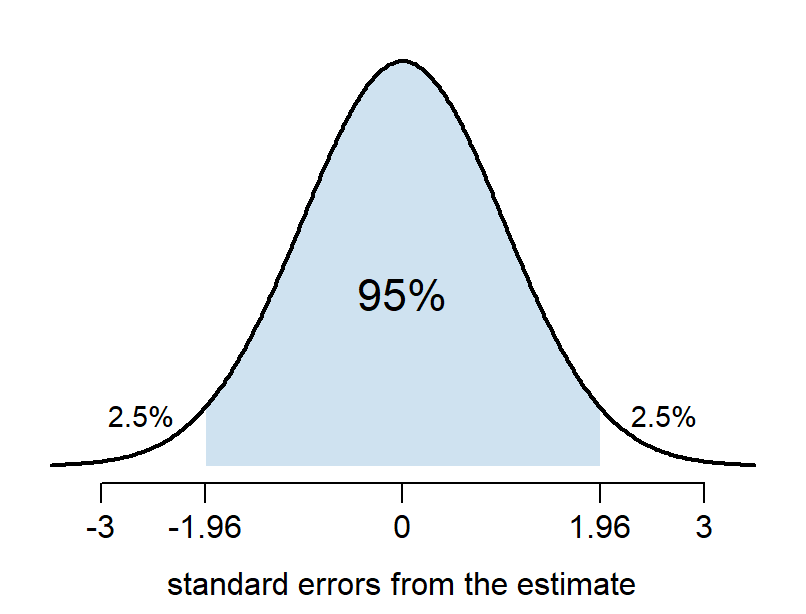

- 95% of a **normal** distribution lies within 1.96 standard deviations of its middle: `qnorm(0.975)` is 1.959964, rounded to 1.96
- **The approximation:** that the estimate is roughly normal, so the likelihood is close to Lecture 17’s **parabola**
- True with plenty of data, away from edges. The logit scale has **no edges**; the probability scale stops at 0 and 1

Build the interval on the link scale, where “roughly normal” is closest to true; then transform the two ends.

## The same band, the easy way

Two packages build the same band for you:

```r
# once: install.packages(c("marginaleffects", "emmeans"))
library(marginaleffects)
predictions(g_occ, newdata = data.frame(elapsed = 22))

library(emmeans)
emmeans(g_occ, ~ elapsed, at = list(elapsed = 22), type = "response")
```

**Check:** both give 65.8%, 61.0% to 70.4%: the same as by hand. emmeans says why: “Intervals are back-transformed from the logit scale”.

# Yes/no data: which songbirds migrate?

## Turning Tuesday around

- Tuesday: how pointed are the wings, **given** migration?
- Today: how likely is a songbird to **migrate**, given where it lives and its wings?
- One row per species: **1** if migratory, **0** if not

**The prediction:** migrants are more likely far from the equator, and among species with pointed wings.

## Get set up

```r
library(ggplot2)

songbirds <- avonet[avonet$Order1 == "Passeriformes", ]
birds <- data.frame(species = songbirds$Species1,
                    hwi = songbirds$Hand.Wing.Index,
                    lat = abs(songbirds$Centroid.Latitude),
                    migratory = as.numeric(songbirds$Migration == 3),  # 1 yes, 0 no
                    mass = songbirds$Mass,                             # g
                    wing = songbirds$Wing.Length)                      # mm
birds <- na.omit(birds)
mean(birds$migratory)
```

**Check:** 6,583 species, as on Tuesday; 8% of them are migratory.

## Why not `lm()`?

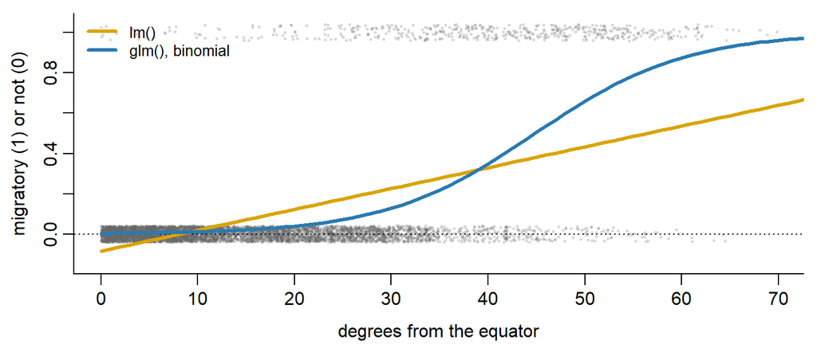

The straight line predicts a **negative** probability at the equator (-0.08), and the scatter around it cannot be normal: every point is 0 or 1.

## Fit it

```r
# for 0/1 data the response is just the 0/1 column
g_lat <- glm(migratory ~ lat, family = binomial, data = birds)
g_add <- glm(migratory ~ lat + hwi, family = binomial, data = birds)

AICtab(g_lat, g_add)
coef(g_add)
```

**Check:** adding wing shape improves AIC by 126; both slopes are positive.

## What the coefficients mean

|  | `coef()`: logit scale | `exp(coef())`: odds ratio |
| --- | --- | --- |
| latitude | 0.116 per degree | × **1.12** per degree (1.11 to 1.13) |
| HWI | 0.075 per unit | × **1.08** per unit (1.06 to 1.09) |

One unit of HWI: Kipp’s distance is 1% more of the wing length.

At 45° from the equator, the chance a songbird migrates is 33% with an HWI of 15, and 60% with an HWI of 30.

## Draw it

```r
# two kinds of songbird: rounded wings (HWI 15) and pointed wings (HWI 30)
grid <- expand.grid(lat = 0:70, hwi = c(15, 30))
p <- predict(g_add, newdata = grid, type = "link", se.fit = TRUE)
grid$prob <- plogis(p$fit)
grid$lwr <- plogis(p$fit - 1.96 * p$se.fit)
grid$upr <- plogis(p$fit + 1.96 * p$se.fit)

ggplot(grid, aes(x = lat, y = prob, fill = factor(hwi))) +
  geom_ribbon(aes(ymin = lwr, ymax = upr), alpha = 0.3) +
  geom_line(aes(color = factor(hwi))) +
  labs(x = "degrees from the equator", y = "probability of migrating",
       fill = "HWI", color = "HWI")
```

**Check:** `grid` has 142 rows; the ribbons stay between 0 and 1.

## Pointed wings, high latitudes

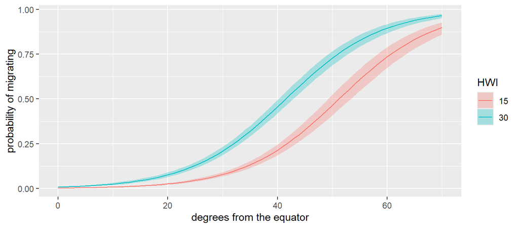

Near the equator, almost no songbird migrates whatever its wings. Past about 40°, wing shape makes a large difference.

## The same figure, the easy way

```r
plot_predictions(g_add, condition = list("lat", hwi = c(15, 30))) +
  labs(x = "degrees from the equator", y = "probability of migrating")
```

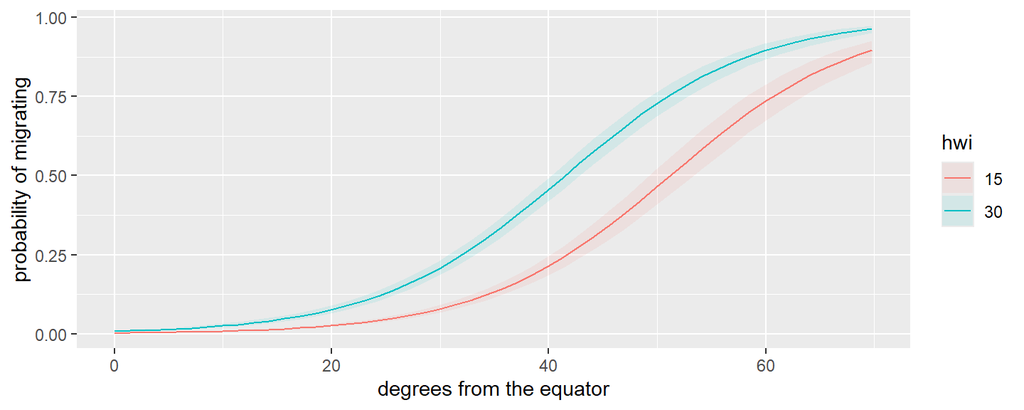

**Check:** the same curves and bands as yours.

# Counts: reef fish

## Poisson first

Fish species per survey, against depth (Lecture 19’s reef surveys):

```r
reef <- reef_surveys
g_pois <- glm(richness ~ depth + I(depth^2), family = poisson, data = reef)
coef(g_pois)

# if the scatter really is Poisson, about 95% of surveys fall in this range
mu <- fitted(g_pois)              # expected richness for each survey
lo <- qpois(0.025, mu)
hi <- qpois(0.975, mu)
mean(reef$richness >= lo & reef$richness <= hi)
```

**Check:** 64%, not 95%. 18% of surveys are above the range and 18% below: the curve is in the right place, but the scatter is far wider than a Poisson allows.

## The fix: a negative binomial

Lecture 18’s answer to extra scatter, as a `glm()`:

```r
g_nb <- MASS::glm.nb(richness ~ depth + I(depth^2), data = reef)

AICtab(g_pois, g_nb)      # as in Lecture 18: Poisson against negative binomial
summary(g_nb)             # glm.nb() calls Lecture 18's k "theta"
```

|  | Poisson | negative binomial |
| --- | --- | --- |
| AIC | 80,033 | 63,513 |
| surveys inside the 95% range | 64% | 97% |
| standard errors | too small | 2.1 times the Poisson’s |

Counts almost always scatter more than a Poisson allows: check, and use glm.nb() when they do.

## Does the fix match the data?

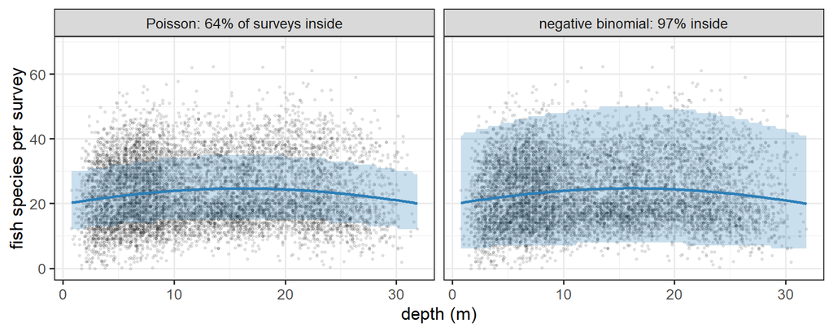

Nearly the same curve in both panels; only the negative binomial’s range is wide enough for real reefs.

# Curves with normal scatter: `nls()`

## `nls()`: a curve, normal scatter

Bolker 9.3: for a mean that is **not** linear in the parameters, with normal scatter, `nls()` is the shortcut. It is `mle2()` with `dnorm()`, written as a formula, and it **does** need starting values.

Example: wing length grows with body mass as a **power law**, $\text{wing} = a \cdot \text{mass}^b$. If shape stayed the same as birds got bigger, $b$ would be $1/3$.

## Fit a power law

```r
# starting values from the log-log line: log(wing) = log(a) + b * log(mass)
start_ll <- coef(lm(log(wing) ~ log(mass), data = birds))

n_wing <- nls(wing ~ a * mass^b, data = birds,
              start = list(a = exp(start_ll[[1]]), b = start_ll[[2]]))
coef(n_wing)
confint.default(n_wing)
```

**Check:** $b$ = 0.397 (0.393 to 0.400), well above 1/3: bigger songbirds have **relatively longer** wings.

# Your turn

## A coral disease reaches the Dry Tortugas

- **Stony coral tissue loss disease** was first seen near Miami in 2014 and spread along Florida’s reef
- **Highly susceptible** species (brain, maze, pillar and star corals) lose living tissue fast, and whole colonies die
- The **Dry Tortugas** were the last part of Florida’s reef without it, until **May 2021**

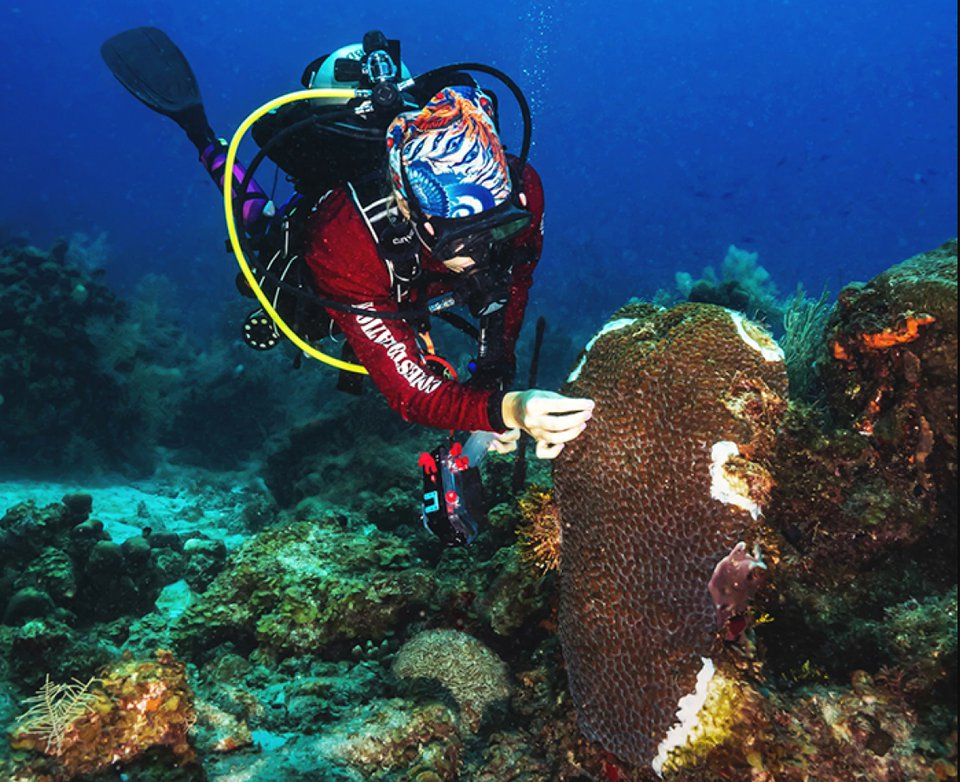

A diver applies antibiotic paste (the white bands) along the edge of a lesion. Photo: Joe Snyder/NOAA, public domain.

NOAA divers recorded what covers the bottom at Tortugas stations in 2016, 2018, 2021 and 2022. **Did susceptible corals disappear from the stations?**

## Your turn: build the data

```r
corals <- coral_cover[coral_cover$REGION == "Tortugas", ]
corals$station <- paste(corals$PRIMARY_SAMPLE_UNIT, corals$STATION_NR, corals$YEAR)

# one row per station visit
stations <- unique(corals[, c("station", "YEAR")])

# 1 if any highly susceptible coral was recorded there, 0 if not
susceptible <- "Colpophyllia|Dendrogyra|Dichocoenia|Diploria|Eusmilia|Meandrina"
found_at <- corals$station[grepl(susceptible, corals$COVER_CAT_NAME)]
stations$found <- as.numeric(stations$station %in% found_at)
stations$year <- factor(stations$YEAR)

tapply(stations$found, stations$year, mean)
```

**Check:** 496 station visits; susceptible corals at 25% of them in 2016.

## Your turn: fit it

```r
# g_null: found ~ 1, a binomial glm with no predictors
# g_year: found ~ year
# compare them with AICtab()

# the probability for each year, with a 95% interval:
# predict on the link scale with se.fit = TRUE for one row per year,
# then plogis() the estimate and both ends
```

**Before you fit:** what should the probability do after 2021?

**Check:** `g_year` wins by 19.0 AIC units; susceptible corals at 25% (18% to 34%) of stations in 2016 and 4% (2% to 10%) in 2022.

**For anyone fast:** check your intervals the easy way, with `emmeans()`. Then: do other corals (`"Siderastrea|Montastraea|Porites"`), which are less susceptible, drop as much? That guards against “the survey changed”.

# Wrapping up

## Which tool, when

| Your response | Function |
| --- | --- |
| continuous, normal scatter, linear mean | `lm()` |
| continuous, normal scatter, curved mean | `nls()` |
| yes/no, or successes out of trials | `glm(family = binomial)` |
| counts | `glm(family = poisson)`, then check the scatter |
| counts with extra scatter | `MASS::glm.nb()` |
| anything else | `mle2()` |

An interval on a `glm()` prediction: `se.fit = TRUE` on the link scale, then undo the link, or `predictions()` and `emmeans()`. For a prediction interval, Lecture 21’s recipe.

## Your call: which model? (1 of 2)

Which function, which link, which predictors? Then click.

| The biology | Model and link | Predictors |
| --- | --- | --- |
| Lizard body temperature (°C) against air temperature, for a basking species and a shade-dwelling one. Do baskers track the air less closely? | `lm()`, no link | `air_temp * species`: different slopes |
| Sea turtle nests: eggs hatched out of each clutch, against sand temperature, on three beaches | `glm()`, binomial, logit; `cbind(hatched, clutch - hatched)` | `temperature + beach` |
| Seedlings per quadrat against canopy openness, in burned and unburned plots | `glm()`, Poisson, log; `glm.nb()` if too scattered | `openness + burned` (`*` if fire changes the light response) |

## Your call: which model? (2 of 2)

| The biology | Model and link | Predictors |
| --- | --- | --- |
| Cogongrass present or absent in 200 plots, against distance to a road and years since fire | `glm()`, binomial, logit, on the 0/1 column | `distance + years_since_fire` |
| Lizard mass against snout-vent length, both sexes; mass grows as a power of length | `nls(mass ~ a * svl^b)`, no link; or `lm(log(mass) ~ log(svl))` | `svl`; separate curves by sex if built differently |
| Mosquito larvae per dip, ponds with and without fish: mostly 0 to 3, a few over 50 | `MASS::glm.nb()`, log link | `fish`, plus pond area if measured |

## Before next class

Read Bolker **chapter 10, sections 10.1 and 10.4** (mixed models: when observations come in groups)

**Assignment 4** is due Friday, November 20, 11:59 pm